# Report - Predictive model of gene expression

Author

Zhuoya Zhao

Published

June 14, 2024

## Introduction

This report describes the fitting of a predictive model of gene expression. The dataset used is from an experiment investigating the effect of a new treatment on gene expression. The variables and descriptions are as follows:

Table 1: Description of the dataset

| variable | class | description |
| --- | --- | --- |
| cell_line | character | Cell lines, including 2 levels, wild type and cell type 101 |
| treatment | character | Treatment, including 2 levels, placebo and activating factor 42 |
| name | character | Name of cell |
| conc | double | Concentration of treatment |
| gene_expression | double | Gene expression |

## Method

This section describes the method for exploring a suitable predictive model for gene expression using R programming.

First, we clean the raw data by converting the character variables in the dataset to lowercase to address the inconsistencies between uppercase and lowercase letters.

Second, we set up a validation split based on the stratification variable `gene_expression`, using a seed of 2024. We then create a 10-fold cross-validation set on the training set.

Third, we create the workflow. In the recipe, we convert all character variables to factor variables. For the model, we perform lasso regression with `mixture = 1` using the `glmnet` engine. We set `penalty = tune()` to tune the regularisation parameter, and generate a grid of evenly spaced parameter values using `grid_regular()`, with 50 levels for one parameter in the grid. We use `autoplot()` to visualize the performance metrics versus the amount of regularisation.

Fourth, we specify RMSE as the assessment metric and select the best regularisation amount with the smallest RMSE using `select_best()`. This allows us to update the final workflow by replacing the `penalty()` with the selected best value. At this point, we obtain the best predictive model.

Finally, we plot the trend of coefficients as the penalty varies.

## Results

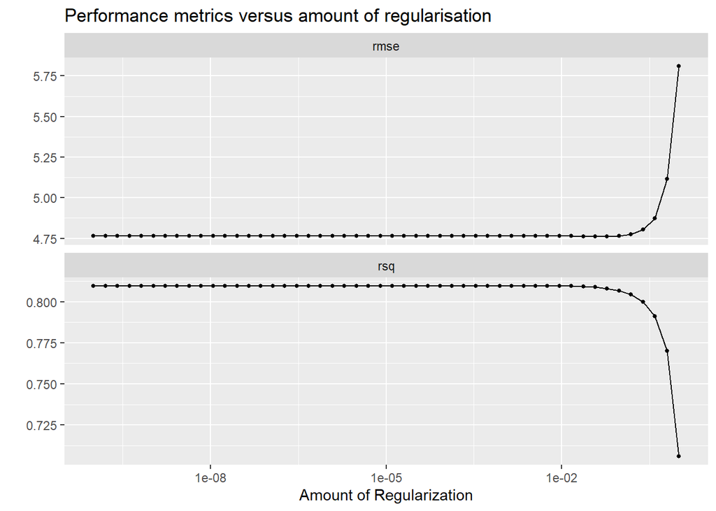

```
══ Workflow ════════════════════════════════════════════════════════════════════
Preprocessor: Recipe
Model: linear_reg()

── Preprocessor ────────────────────────────────────────────────────────────────
1 Recipe Step

• step_dummy()

── Model ───────────────────────────────────────────────────────────────────────
Linear Regression Model Specification (regression)

Main Arguments:
  penalty = 0.0372759372031494
  mixture = 1

Computational engine: glmnet
```

The VIP plot below shows the most influential variables with importance scores greater than 1. We can see that the cell `gl.xik` has the most positive influence on the model’s predictions, while the cell `gl.zhw` has the most negative influence. The treatment `placebo` has the second most negative influence, and the wild-type cell line has the third most negative influence. The importance of other variables is much smaller.

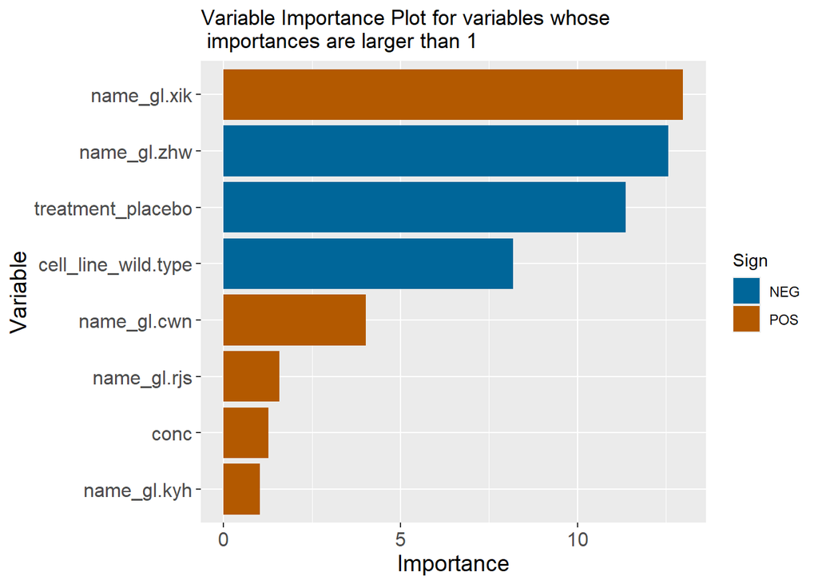

In the following plot, the coefficients of variables are regularised towards zero as the penalty increases:

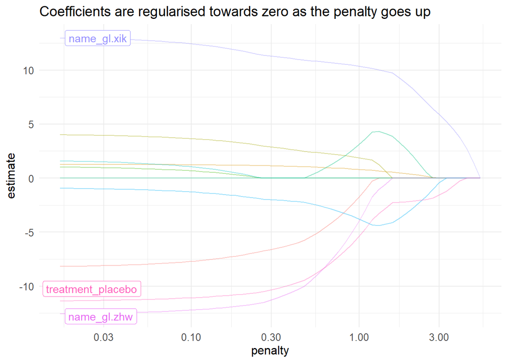

```
# A tibble: 2 × 4
  .metric .estimator .estimate .config
  <chr>   <chr>          <dbl> <chr>
1 rmse    standard       5.29  Preprocessor1_Model1
2 rsq     standard       0.780 Preprocessor1_Model1
```

## Appendix

```r
pacman::p_load(tidyverse, tidymodels, textrecipes, readxl, ggplot2)
df = read_xlsx(path = here::here("raw-data","WIF-tis4d.xlsx"), na ="") # load data
df = df |>
  mutate(across(where(is.character), tolower)) # clean data
set.seed(2024)
split = initial_split(df, strata = "gene_expression") # split into training and tesing set
train = training(split)
test = testing(split)
cv = vfold_cv(train) # 10-fold cross-validation set on the training set
recipe = # recipe in workflow
  recipe(gene_expression ~ ., data = train) |>
  step_dummy(all_nominal_predictors()) # factor variables

model = # model in workflow
  linear_reg(penalty = tune(), mixture = 1) |> # lasso regression
  set_mode("regression") |>
  set_engine("glmnet") # engine

wf = workflow(recipe, model)
doParallel::registerDoParallel()

grid = grid_regular(penalty(), levels = 50) # a grid of evenly spaced parameter value

tune = tune_grid( # tune parameters on the grid
  wf,
  resamples = cv,
  grid = grid
  )
tune |> autoplot() +
  labs(
    title  = "Performance metrics versus amount of regularisation"
  )
penalty = select_best(tune, metric = "rmse") # according to the smallest RMSE
wf = wf |>
  finalize_workflow(penalty) # use the most suitable parameter
wf
fit = wf |> fit(train) # fit on training set
fit |> # VIP plot
  extract_fit_parsnip() |>
  vip::vi() |>
  filter(Importance > 1) |> #
  mutate(
    Variable = str_remove_all(Variable, "tfidf_review_"),
    Variable = fct_reorder(Variable, Importance)
  ) |>
  ggplot(aes(Importance, Variable, fill = Sign)) +
  geom_col() +
  labs(
    title  = "Variable Importance Plot for variables whose \n importances are larger than 1"
  ) +
  theme(
    axis.title.x = element_text(size = 14),
    axis.title.y = element_text(size = 14),
    axis.text.x = element_text(size = 12),
    axis.text.y = element_text(size = 12)
    )+
  harrypotter::scale_fill_hp_d("Ravenclaw")
fit |> extract_fit_engine() |> autoplot() +
  labs(
    title = "Coefficients are regularised towards zero as the penalty goes up"
  ) +
  theme_minimal() +  # apply a minimal theme
  theme(
    axis.title.x = element_text(size = 12),
    axis.title.y = element_text(size = 12),
    axis.text.x = element_text(size = 10),
    axis.text.y = element_text(size = 10),
    plot.title = element_text(size = 14)

  )
last_fit(wf, split) |> collect_metrics()
```